# Análise das atividades dos congressistas no Twitter em 2019

**Aluno:** Johanny de Lucena Santos  
**Atividade:** Lab 1 - Parte 2

### Lendo os dados do repositório

```r
atividade = read_projectdata()
```

**Observação:** Os dados brutos têm 72.316 tweets cuja data de criação segundo a API é em 2019. Esses tweets foram coletados em 22 de março de 2019. O script que os processa, cruza com a lista de parlamentares conhecidos e salva a atividade por parlamentar.

Com base nesse conjunto de base, elaborei duas questões para responder.

### Filtrando apenas os parlamentares que possuem conta no Twitter

Aqui, removo do conjunto de dados os parlamentares que não possuem conta no Twitter.

```r
parlamentares_twitter = atividade %>%
  filter(!is.na(twitter))
```

### Removendo os parlamentares que não têm seguidores nem segue pelo menos uma pessoa

Fazendo uma análise visual rápida no novo conjunto de dados, é possível ver que muitos parlamentares não tem seguidores, ou não seguem algum perfil, e analisando esses, não tem dados de engajamento ou de tweets próprios ou retweets, por isso, considerei que, apesar de terem a conta no Twitter, não realizam atividades no mesmo.

```r
parlamentares_seguidores = parlamentares_twitter %>%
  filter(!is.na(seguidores) & !is.na(segue))
```

### Quais partidos possuem parlamentares com maior engajamento?

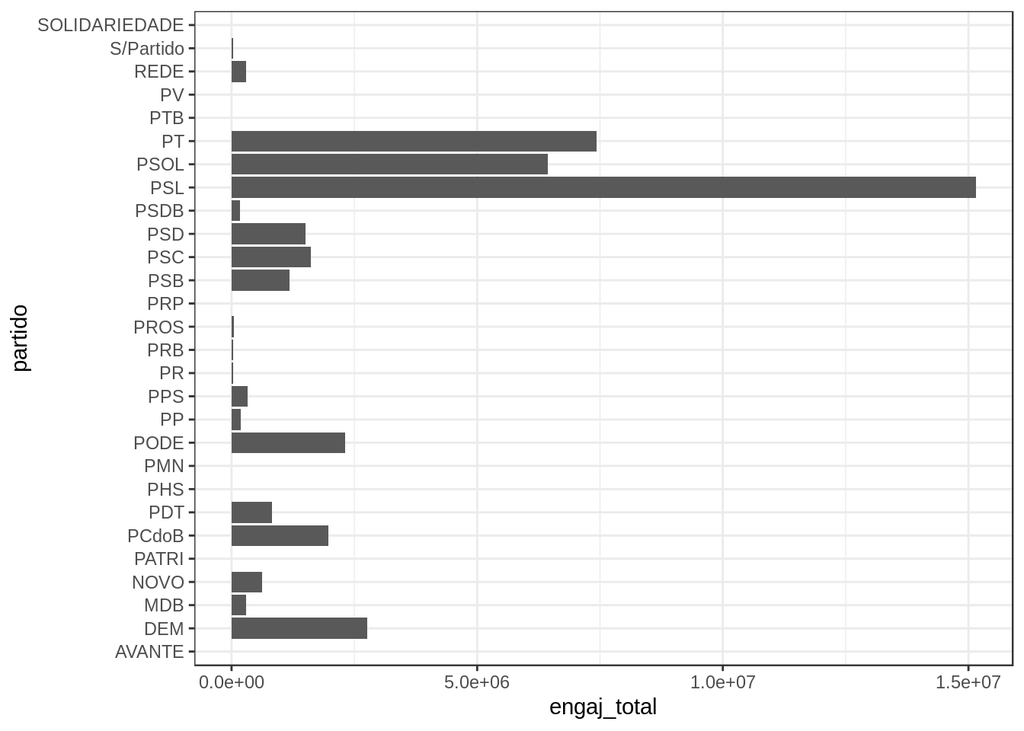

```r
parlamentares_seguidores %>%
  ggplot(aes(x = partido, y = engaj_total)) +
  geom_col() +
  coord_flip()
```

Com base no gráfico gerado acima, podemos ver que os três partidos que possuem maior engajamento no Twitter são, em ordem decrescente, **PSL** (engajamento muito maior que o segundo colocado), **PT** e **PSOL**. Possivelmente, o fato do atual presidente do Brasil ser do partido PSL pode ter impulsionado o número de likes ou retweets nos perfis dos parlamentares deste partido.